# Week 9: Regression

PS 812 - Introduction to Statistical Methods in Political Science

Anton Strezhnev

strezhnev@wisc.edu

University of Wisconsin-Madison

November 3, 2026

## Welcome back!

$$\newcommand{\Var}{\text{Var}}
\newcommand{\Cov}{\text{Cov}}
\newcommand{\Corr}{\text{Corr}}
\newcommand{\indep}{\mathrel{\perp\mkern-10mu\perp}}$$

## Where we’ve been

## Where we’ve been

## Where we’ve been

Gelman and Carlin (2014)

## Where we’ve been

## Where we’re going

## Regression

- In the social sciences, we often want to understand how our **prediction** for an outcome variable $Y_i$ changes depending on the values of some set of covariates $\mathbf{X}_i$
  - **Description**: A parsimonious summary of the data
  - **Forecasting**: Given a *new* value of $\mathbf{X}_i$, what’s our best prediction for $Y_i$?
  - **Adjustment for causal inference**: Can we **explain away** $Y_i$ with confounders $\mathbf{X}_i$ to make our causal assumptions more credible?
- In all cases, our **estimand** changes from a single parameter to a **function**
  - The **conditional expectation function**

  $$\mu(\mathbf{x}) = \mathbb{E}[Y_i \mid \mathbf{X}_i = \mathbf{x}]$$

## Running Example: Hostile sexism and support for Trump

- Do **gender attitudes** predict support for right-wing political candidates even after we adjust for partisanship?
  - One particular attitude measured by political psychologists is **hostile sexism**
    - Antagonism towards women seen as seeking power or challenging traditional gender roles (Glick and Fiske 1996)
  - In 2016, hostile sexism predicted support for Trump over Clinton even after adjusting for partisanship and other predictors (Winter 2023).
    - Additionally, it appears to contribute to the **education gap** in political attitudes among white voters (Schaffner et al. 2018)
  - Does the relationship hold up in 2024?
- **Outcome** $Y_i$: Trump feeling thermometer (0-100) from the 2024 ANES (American National Election Studies 2026)
- **Regressor** $X_i$: responses to four statements, each on a 5-point scale, rescaled to $[0, 1]$ and averaged
  1. “Many women interpret innocent remarks or acts as being sexist.” (agree-disagree)
  2. “Women seek to gain power by getting control over men.” (agree-disagree)
  3. “When women demand equality these days, how often are they actually seeking special favors?” (always-never)
  4. “When women complain about discrimination, how often do they cause more problems than they solve?” (always-never)

## Marginal distributions

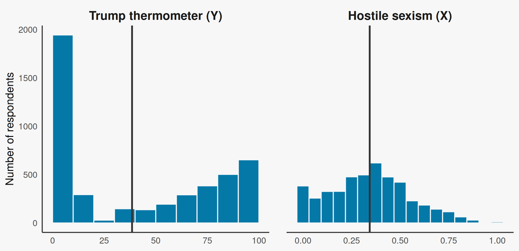

## Hostile sexism and support for Trump

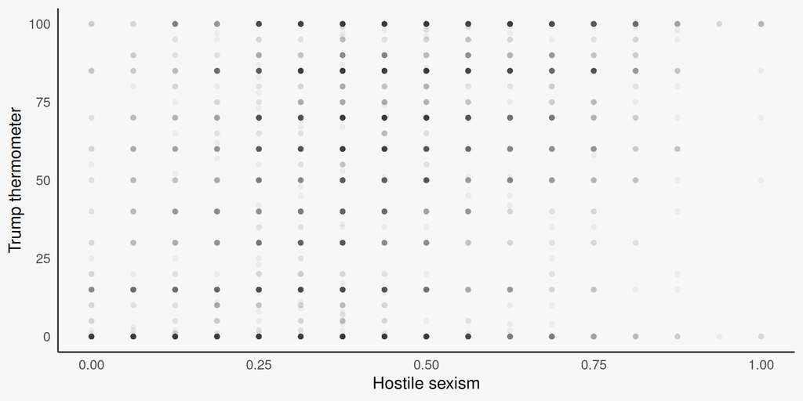

## Why models?

- It might seem like we can just use the same **sample mean** estimator as before but on **subsets of the data**
  - With discrete covariates, **we can!**
  - Regression is just taking a **conditional** mean.
- Suppose we separated our respondents into two “bins”: high sexism and low sexism
  - Call respondents who agree with the statements on average ($X_i > 0.5$) **high** and those below **low**
  - The CEF is just **two** distinct quantities.
  - We can estimate each by a **sample mean** within its group

    $$\hat{\mu}(\text{high}) = \frac{1}{n_{\text{high}}}\sum_{i : X_i > 0.5} Y_i \qquad \widehat{SE}\left(\hat{\mu}(\text{high})\right) = \frac{\hat{\sigma}_{\text{high}}}{\sqrt{n_{\text{high}}}}$$
  - Everything from the last three weeks carries through.
    - Under i.i.d. sampling from the target population, it’s unbiased, consistent, asymptotically normal

## Two groups

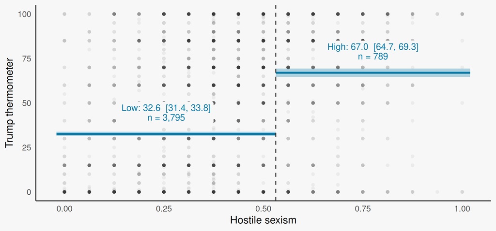

- High-sexism respondents rate Trump 34.4 points more warmly.

## Binning on every value of $X$

- Our hostile sexism measure only has **17** distinct values. We can calculate a conditional mean at **every** one
  $$\hat{\mu}(x) = \frac{1}{n_x}\sum_{i : X_i = x} Y_i \qquad n_x = \sum_{i=1}^n I(X_i = x)$$
- **No assumptions** about the shape of $\mu(x)$. Our estimator is fully **nonparametric**
- But the precision at each $x$ depends **only** on $n_x$: $\widehat{SE}\left(\hat{\mu}(x)\right) = \hat{\sigma}_x / \sqrt{n_x}$
  - Some bins are very small!

## Binning on every value of $X$

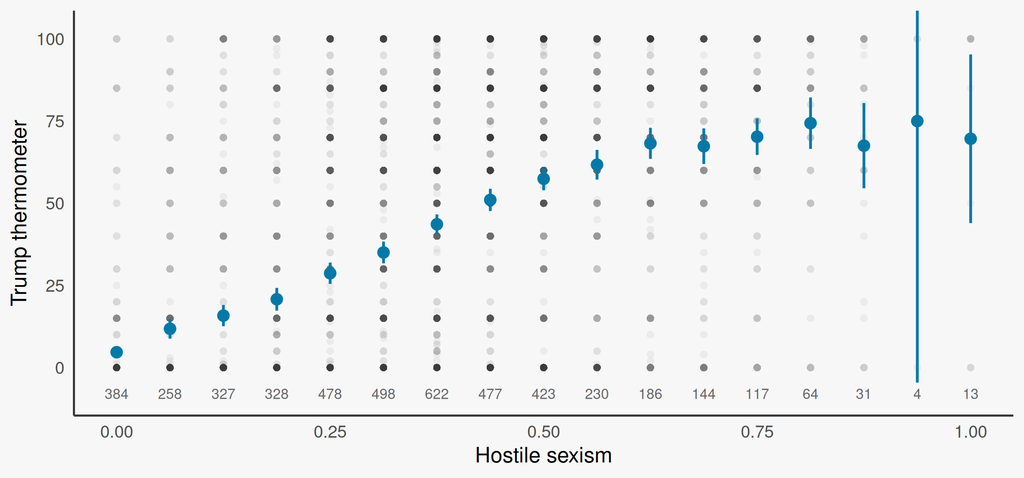

- Support rises until about $0.6$ and then appears to **level off**
- We pay for flexibility with **variance**: the top two bins only hold 4 and 13 respondents!

## The curse of dimensionality

- Binning worked because $X_i$ is **one** variable with **17** values, and we have thousands of respondents
- What if we want the CEF given hostile sexism **and** gender, education, race, partisanship, ideology and age?
  $$\mu(\mathbf{x}) = \mathbb{E}[Y_i \mid \mathbf{X}_i = \mathbf{x}] \qquad \mathbf{X}_i = (X_{i1}, X_{i2}, \dotsc, X_{ik})$$
  - Binning needs a separate mean for **every combination** of covariate values
  - And if we have a **continuous** covariate, nearly *every* respondent has a unique value of that covariate
- This is the **curse of dimensionality**
  - As the number of covariates grows, the covariate **space** grows exponentially

## The curse of dimensionality

| Conditioning on | Possible bins | Non-empty bins | Median bin size | Alone in bin | In a bin of < 10 |
| --- | --- | --- | --- | --- | --- |
| Hostile sexism | 17 | 17 | 353 | 0% | 0% |
| + gender | 51 | 45 | 176 | 0% | 1% |
| + college degree | 102 | 81 | 95 | 0% | 2% |
| + race | 510 | 292 | 57 | 2% | 19% |
| + party ID (7 pt.) | 3,570 | 905 | 10 | 11% | 48% |
| + ideology (7 pt.) | 24,990 | 1,700 | 3 | 27% | 83% |
| + age | 1,574,370 | 3,609 | 1 | 90% | 100% |

- 3,810 respondents with every covariate observed. Once we condition on party ID and ideology, the typical respondent shares their covariate bin with only 2 others
- Add age, and 90% of respondents have *unique* covariate profiles.

## Borrowing strength

- To estimate $\mu(\mathbf{x})$ where we have little data, we have to use observations at **other** values of $\mathbf{X}_i$
- That requires **assumptions** about how $\mu(\cdot)$ behaves between the points we observe.
- For example:
  - **Smoothness**: $\mu(\cdot)$ doesn’t change much between nearby $\mathbf{x}$
  - **Functional form**: $\mu(\cdot)$ has a particular shape everywhere (e.g. a line)
- This is why we need **models**. More covariates, more need to impose structure **ex-ante**
- Some alternative estimation strategies:
  - **Kernel estimators**: Average the observations *near* $\mathbf{x}$ when estimating $\mu(\mathbf{x})$
  - **Linear regression**: Assume a shape for $\mu(\cdot)$ and use **all** of the data to estimate the function.

## Local averaging

- Instead of averaging only the exact matches, average every observation within a **window** $h/2$ of $x$
  $$\hat{\mu}(x) = \frac{\sum_{i=1}^n I\left(|X_i - x| \le \tfrac{h}{2}\right) Y_i}{\sum_{i=1}^n I\left(|X_i - x| \le \tfrac{h}{2}\right)}$$
- This is the same idea as our **kernel density** estimator but applied to **regression**
  - Calculate the mean at each $x$ using a window centered on $x$
- The width $h$ is a **tuning parameter**
  - Too small: few observations in each window $\leadsto$ **noisy** estimator
  - Too large: we average over a region where $\mu(x)$ changes $\leadsto$ **bias**
- Here, we’re assuming a **uniform** kernel
  - But as before, we can instead let the weight on each observation **fall** with its distance from $x$

## Nadaraya-Watson kernel regression

- The **Nadaraya-Watson** estimator (Nadaraya 1964; Watson 1964)
  $$\hat{\mu}_h(\mathbf{x}) = \frac{\sum_{i=1}^n K_h(\mathbf{X}_i - \mathbf{x})\, Y_i}{\sum_{i=1}^n K_h(\mathbf{X}_i - \mathbf{x})} = \sum_{i=1}^n w_i(\mathbf{x})\, Y_i \qquad w_i(\mathbf{x}) = \frac{K_h(\mathbf{X}_i - \mathbf{x})}{\sum_{j=1}^n K_h(\mathbf{X}_j - \mathbf{x})}$$
- A **weighted average** of the outcomes: the weights are non-negative, sum to $1$, and are larger for the observations closer to $\mathbf{x}$
- The same kernels as in density estimation, $K_h(\mathbf{u}) = K(\mathbf{u}/h)$
  - With $k$ dimensions, often use the **product kernel**: $K(\mathbf{u}) = \prod_{j=1}^k K(u_j)$ (with covariates on a common scale)
    - The product of covariate-specific kernels (which can be uniform/triangular/etc…)
  - Another approach is the **“nearest neighbors”** method: at each $x$, average the outcomes of the $m$ closest observations (based on some distance metric)
    - Larger windows in *sparser* parts of the covariate space.

## The kernel weights

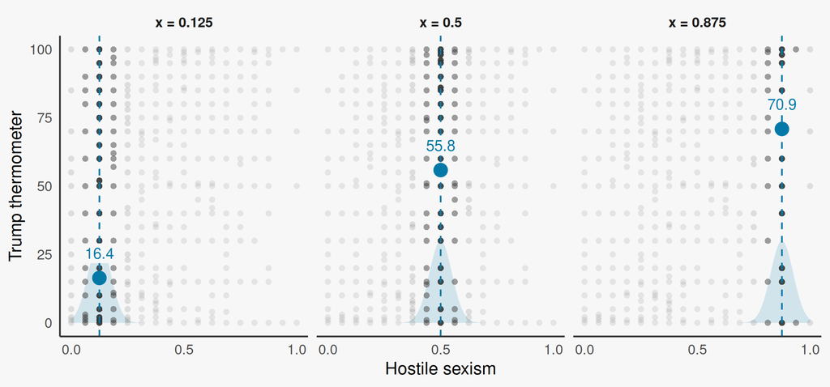

- Gaussian kernel, $h = 0.05$

## Nadaraya-Watson in R

```r
# Nadaraya-Watson with a Gaussian kernel: a weighted mean of Y around x0
nw <- function(x0, x, y, h) {
  w <- dnorm((x - x0) / h)
  sum(w * y) / sum(w)
}

grid <- (0:100) / 100
nw_fit <- tibble(hostile_sexism = grid,
                 fit = map_dbl(grid, nw, x = anes$hostile_sexism,
                               y = anes$ft_trump, h = 0.05))
nw_fit |> filter(hostile_sexism %in% c(0, 0.25, 0.5, 0.75, 1))
```

```
# A tibble: 5 × 2
  hostile_sexism   fit
           <dbl> <dbl>
1           0     6.63
2           0.25 29.2
3           0.5  55.8
4           0.75 69.8
5           1    70.1
```

## Choosing the bandwidth

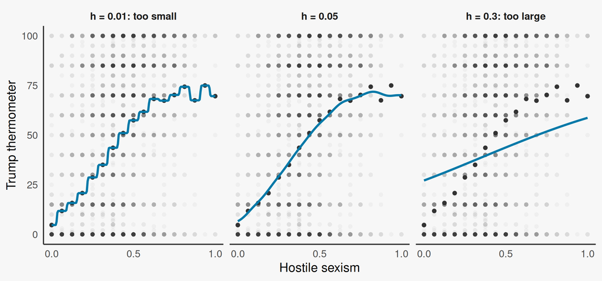

- The bias depends on how much $\mu(\cdot)$ **curves** and whether $\mathbf{X}_i$ are *lopsided* around $\mathbf{x}$
- The variance depends on $\Var(Y_i \mid \mathbf{X}_i = \mathbf{x})$ and on how many observations are around $\mathbf{x}$

## From a local to a global estimator

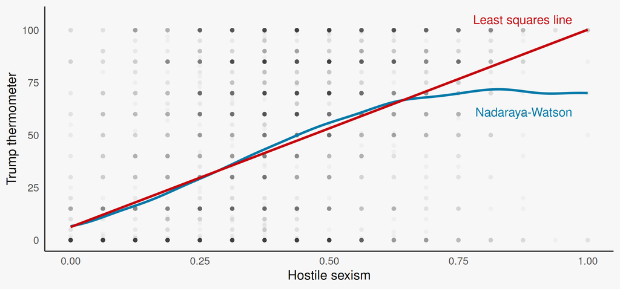

- What if we **assume** the CEF is a line, $\mu(x) = \beta_0 + \beta_1 x$?
  - Regardless of how many values $X_i$ takes, we’re only ever estimating **two** things
- Every observation informs the fit at **every** $x$, so the line is more **precise**
  - But at the cost of bias. Where $\mu(\cdot)$ bends, the line is **biased** for the true CEF

## Linear regression and ordinary least squares

## Best Linear Predictor

- Let’s restrict our focus to functions of $X$ that are **linear predictors**
  - That is, they’re **linear** combinations of the covariates and some set of **parameters**
- With a single covariate

  $$m(x) = \beta_0 + \beta_1 x$$
- With **many covariates**, we write

  $$m(\mathbf{x}) = \beta_0 + \beta_1 x_1 + \dotsc + \beta_{k-1} x_{k-1} = \mathbf{x}^\prime\boldsymbol{\beta}$$

  $$\mathbf{x} = (1, x_1, \dotsc, x_{k-1})^\prime \qquad \boldsymbol{\beta} = (\beta_0, \beta_1, \dotsc, \beta_{k-1})^\prime$$
- **Review**: Inner products

  $$\underbrace{\mathbf{x}^\prime}_{1 \times k} \quad \underbrace{\boldsymbol{\beta}}_{k \times 1} = \begin{pmatrix} 1 & x_1 & x_2 & \cdots & x_{k-1} \end{pmatrix} \begin{pmatrix} \beta_0 \\ \beta_1 \\ \beta_2 \\ \vdots \\ \beta_{k-1} \end{pmatrix} = 1 \cdot \beta_0 + x_1 \beta_1 + x_2 \beta_2 + \dotsc + x_{k-1} \beta_{k-1}$$

## Best Linear Predictor

- The **best linear predictor** is the linear predictor that **minimizes** the expected squared prediction error

  $$\boldsymbol{\beta} = \arg\min_{\mathbf{b} \in \mathbb{R}^k} \ \mathbb{E}\big[(Y_i - \mathbf{X}_i^\prime\mathbf{b})^2\big]$$
- We found a **closed form solution** for the two-parameter case in a previous lecture

  $$\beta_1 = \frac{\Cov(X_i, Y_i)}{\Var(X_i)} \qquad \beta_0 = \mathbb{E}[Y_i] - \beta_1\,\mathbb{E}[X_i]$$
- Let’s derive the **general form** for *many* covariates

## Best Linear Predictor

- We’ll start by taking the **partial derivatives** of the squared errors inside the expectation with respect to the **parameters**

  $$\begin{aligned}
  \frac{\partial}{\partial \mathbf{b}} (Y_i - \mathbf{X}_i^\prime\mathbf{b})^2 &= \begin{pmatrix} \frac{\partial}{\partial b_0} (Y_i - \mathbf{X}_i^\prime\mathbf{b})^2 \\ \vdots \\ \frac{\partial}{\partial b_{k-1}} (Y_i - \mathbf{X}_i^\prime\mathbf{b})^2 \end{pmatrix} = \begin{pmatrix} -2 \cdot 1 \cdot (Y_i - \mathbf{X}_i^\prime\mathbf{b}) \\ \vdots \\ -2 X_{i,k-1} (Y_i - \mathbf{X}_i^\prime\mathbf{b}) \end{pmatrix} \\[0.4em]
  &= -2\,\mathbf{X}_i (Y_i - \mathbf{X}_i^\prime\mathbf{b}) = -2\,(\mathbf{X}_i Y_i - \mathbf{X}_i\mathbf{X}_i^\prime\mathbf{b})
  \end{aligned}$$
- Review: outer products

  $$\underbrace{\mathbf{X}_i}_{k \times 1} \quad \underbrace{\mathbf{X}_i^\prime}_{1 \times k} = \begin{pmatrix} 1 \\ X_{i1} \\ \vdots \\ X_{i,k-1} \end{pmatrix} \begin{pmatrix} 1 & X_{i1} & \cdots & X_{i,k-1} \end{pmatrix} = \begin{pmatrix} 1 & X_{i1} & \cdots & X_{i,k-1} \\ X_{i1} & X_{i1}^2 & \cdots & X_{i1} X_{i,k-1} \\ \vdots & \vdots & \ddots & \vdots \\ X_{i,k-1} & X_{i,k-1} X_{i1} & \cdots & X_{i,k-1}^2 \end{pmatrix}$$

## Best Linear Predictor

- Take the **expected value** and set it equal to $\mathbf{0}$ to solve for $\boldsymbol{\beta}$

  $$\begin{aligned}
  \mathbb{E}\big[{-2}\,(\mathbf{X}_i Y_i - \mathbf{X}_i\mathbf{X}_i^\prime\boldsymbol{\beta})\big] &= \mathbf{0} \\
  \mathbb{E}[\mathbf{X}_i Y_i] - \mathbb{E}[\mathbf{X}_i\mathbf{X}_i^\prime]\,\boldsymbol{\beta} &= \mathbf{0} \\
  \mathbb{E}[\mathbf{X}_i\mathbf{X}_i^\prime]\,\boldsymbol{\beta} &= \mathbb{E}[\mathbf{X}_i Y_i] \\
  \boldsymbol{\beta} &= \big(\mathbb{E}[\mathbf{X}_i\mathbf{X}_i^\prime]\big)^{-1}\,\mathbb{E}[\mathbf{X}_i Y_i]
  \end{aligned}$$
- What have we **assumed**?
- Essentially just **regularity conditions** that ensure the BLP **exists**
  - Finite mean/variance for $Y$
  - Finite means/variances/covariances for $\mathbf{X}$
  - $(\mathbb{E}[\mathbf{X}_i\mathbf{X}_i^\prime])^{-1}$ exists (no **perfect** linear dependence between covariates)

## Projection error

- What are the properties of the **error** between the true $Y_i$ and the **best linear predictor**?

  $$e_i = Y_i - m(\mathbf{X}_i) = Y_i - \mathbf{X}_i^\prime\boldsymbol{\beta}$$
- One very important property is that the projection errors are **uncorrelated** with the covariates

  $$\begin{aligned}
  \mathbb{E}[\mathbf{X}_i e_i] &= \mathbb{E}\big[\mathbf{X}_i (Y_i - \mathbf{X}_i^\prime\boldsymbol{\beta})\big] \\
  &= \mathbb{E}[\mathbf{X}_i Y_i] - \mathbb{E}[\mathbf{X}_i\mathbf{X}_i^\prime]\,\boldsymbol{\beta} \\
  &= \mathbb{E}[\mathbf{X}_i Y_i] - \mathbb{E}[\mathbf{X}_i\mathbf{X}_i^\prime]\big(\mathbb{E}[\mathbf{X}_i\mathbf{X}_i^\prime]\big)^{-1}\mathbb{E}[\mathbf{X}_i Y_i] \\
  &= \mathbb{E}[\mathbf{X}_i Y_i] - \mathbb{E}[\mathbf{X}_i Y_i] = \mathbf{0}
  \end{aligned}$$

  $$\text{First entry of } \mathbf{X}_i \text{ is } 1 \;\Rightarrow\; \mathbb{E}[e_i] = 0 \;\Rightarrow\; \Cov(X_{ij}, e_i) = \mathbb{E}[X_{ij}\, e_i] - \mathbb{E}[X_{ij}]\,\mathbb{E}[e_i] = 0$$
- This holds **mechanically** with respect to the BLP - no assumptions beyond the regularity conditions above!

## Ordinary Least Squares

- We have defined the **population** best linear predictor from a **minimization** problem

  $$m(\mathbf{x}) = \mathbf{x}^\prime \boldsymbol{\beta} \qquad \boldsymbol{\beta} = \arg\min_{\mathbf{b} \in \mathbb{R}^k} \ \mathbb{E}\big[(Y_i - \mathbf{X}_i^\prime\mathbf{b})^2\big]$$
- And we’ve written $\boldsymbol{\beta}$ as a function of population expectations, $\mathbb{E}[\mathbf{X}_i\mathbf{X}_i^\prime]$ and $\mathbb{E}[\mathbf{X}_iY_i]$

  $$\boldsymbol{\beta} = \big(\mathbb{E}[\mathbf{X}_i\mathbf{X}_i^\prime]\big)^{-1}\,\mathbb{E}[\mathbf{X}_i Y_i]$$
- How do we estimate $\boldsymbol{\beta}$ from an i.i.d. **sample** from the target population?
- **Plug-in principle again**: replace each population expectation with a **sample mean**

  $$\hat{\boldsymbol{\beta}} = \left(\frac{1}{n}\sum_{i=1}^n \mathbf{X}_i\mathbf{X}_i^\prime\right)^{-1} \left(\frac{1}{n}\sum_{i=1}^n \mathbf{X}_iY_i\right)$$

## Why “least squares”?

- We get the same estimator by applying the plug-in principle to the **minimization problem**
  - Minimize the **sample** mean of the squared errors

  $$\hat{\boldsymbol{\beta}} = \arg\min_{\mathbf{b} \in \mathbb{R}^k} \ \frac{1}{n}\sum_{i=1}^n (Y_i - \mathbf{X}_i^\prime\mathbf{b})^2$$
- **Ordinary least squares** (OLS): the coefficients with the smallest **sum of squared residuals** (SSR)
- The same derivative as before but with a sample mean in place of the expectation gives the **normal equations**

  $$\frac{1}{n}\sum_{i=1}^n \mathbf{X}_i (Y_i - \mathbf{X}_i^\prime\hat{\boldsymbol{\beta}}) = \mathbf{0}$$
- So the **residuals** $\hat{e}_i = Y_i - \mathbf{X}_i^\prime\hat{\boldsymbol{\beta}}$ have the sample version of the projection error property
  - They average to $0$ and are uncorrelated with every covariate **in the sample**, by construction

## OLS in matrix form

- We’ll typically talk about the **data** in terms of an $n$-length outcome vector and an $n \times k$ matrix of regressors
  - One **row** per respondent and one **column** per variable.

  $$\underbrace{\mathbf{Y}}_{n \times 1} = \begin{pmatrix} Y_1 \\ Y_2 \\ \vdots \\ Y_n \end{pmatrix} \qquad \underbrace{\mathbf{X}}_{n \times k} = \begin{pmatrix} \mathbf{X}_1^\prime \\ \mathbf{X}_2^\prime \\ \vdots \\ \mathbf{X}_n^\prime \end{pmatrix} = \begin{pmatrix} 1 & X_{11} & \cdots & X_{1,k-1} \\ 1 & X_{21} & \cdots & X_{2,k-1} \\ \vdots & \vdots & \ddots & \vdots \\ 1 & X_{n1} & \cdots & X_{n,k-1} \end{pmatrix}$$
- The sums in $\hat{\boldsymbol{\beta}}$ are **matrix products**

  $$\sum_{i=1}^n \mathbf{X}_i\mathbf{X}_i^\prime = \mathbf{X}^\prime\mathbf{X} \qquad \sum_{i=1}^n \mathbf{X}_iY_i = \mathbf{X}^\prime\mathbf{Y}$$
- The $\frac{1}{n}$’s cancel, which gives the common formula for OLS that you will often see:

  $$\hat{\boldsymbol{\beta}} = (\mathbf{X}^\prime\mathbf{X})^{-1}\mathbf{X}^\prime\mathbf{Y}$$

## Review: matrix multiplication

- A $p \times n$ matrix times an $n \times q$ matrix is $p \times q$.
  - Entry $(j, l)$ is the **inner product** of row $j$ of the first and column $l$ of the second
- Column $i$ of $\mathbf{X}^\prime$ is $\mathbf{X}_i$ and row $i$ of $\mathbf{X}$ is $\mathbf{X}_i^\prime$, so $\mathbf{X}^\prime\mathbf{X}$ is a **sum of outer products**

  $$\underbrace{\mathbf{X}^\prime}_{k \times n} \quad \underbrace{\mathbf{X}}_{n \times k} = \begin{pmatrix} \mathbf{X}_1 & \mathbf{X}_2 & \cdots & \mathbf{X}_n \end{pmatrix} \begin{pmatrix} \mathbf{X}_1^\prime \\ \mathbf{X}_2^\prime \\ \vdots \\ \mathbf{X}_n^\prime \end{pmatrix} = \mathbf{X}_1\mathbf{X}_1^\prime + \mathbf{X}_2\mathbf{X}_2^\prime + \dotsc + \mathbf{X}_n\mathbf{X}_n^\prime$$
- Written out, $\mathbf{X}^\prime\mathbf{X}$ holds the **sums of squares and cross-products** of the columns of $\mathbf{X}$

  $$\mathbf{X}^\prime\mathbf{X} = \begin{pmatrix} n & \sum_i X_{i1} & \cdots & \sum_i X_{i,k-1} \\ \sum_i X_{i1} & \sum_i X_{i1}^2 & \cdots & \sum_i X_{i1}X_{i,k-1} \\ \vdots & \vdots & \ddots & \vdots \\ \sum_i X_{i,k-1} & \sum_i X_{i,k-1}X_{i1} & \cdots & \sum_i X_{i,k-1}^2 \end{pmatrix} \qquad \mathbf{X}^\prime\mathbf{Y} = \begin{pmatrix} \sum_i Y_i \\ \sum_i X_{i1}Y_i \\ \vdots \\ \sum_i X_{i,k-1}Y_i \end{pmatrix}$$

## When does the OLS estimator exist?

- For the BLP, we assumed $\mathbb{E}[\mathbf{X}_i\mathbf{X}_i^\prime]$ is **invertible**
  - The sample version of this is that $\mathbf{X}^\prime\mathbf{X}$ must be invertible
- $\mathbf{X}^\prime\mathbf{X}$ is invertible if and only if $\mathbf{X}$ has **full column rank**

  $$\text{rank}(\mathbf{X}) = k$$
  - No column of $\mathbf{X}$ is a **linear combination** of the others
    - We have no **perfect** collinearity
  - And we need at least as many observations as coefficients, $n \geq k$
- Without full rank there is no **unique** $\hat{\boldsymbol{\beta}}$ since there are **multiple** solutions which achieve the same minimum sum of squares.

## Review: linear combinations and rank

- A **linear combination** of the vectors $\mathbf{a}_1, \dotsc, \mathbf{a}_k$ is a weighted sum. A matrix times a vector is a linear combination of the matrix’s **columns**

  $$\mathbf{A}\mathbf{c} = c_1\mathbf{a}_1 + c_2\mathbf{a}_2 + \dotsc + c_k\mathbf{a}_k$$
- The columns are **linearly independent** if the only combination equal to $\mathbf{0}$ is the trivial one: $\mathbf{A}\mathbf{c} = \mathbf{0} \implies \mathbf{c} = \mathbf{0}$
- The **rank** of a matrix is the largest number of linearly independent columns it contains

  $$\mathbf{A} = \begin{pmatrix} 1 & 2 & 3 \\ 1 & 0 & 1 \\ 1 & 5 & 6 \\ 1 & 1 & 2 \end{pmatrix} \qquad \mathbf{a}_1 + \mathbf{a}_2 - \mathbf{a}_3 = \mathbf{0} \qquad \text{rank}(\mathbf{A}) = 2 < 3$$

## Example: dummy variables

- Consider three party categories: **Democrat**, **Independent** and **Republican**
  - Code each category as a **dummy** (indicator) variable, e.g. $X_i^{\text{Rep}} = I(\text{party}_i = \text{Republican})$
- What if we include an intercept **and** all three dummies?

  $$\begin{array}{l|cccc} & 1 & X^{\text{Dem}} & X^{\text{Ind}} & X^{\text{Rep}} \\ \hline \text{Democrat} & 1 & 1 & 0 & 0 \\ \text{Republican} & 1 & 0 & 0 & 1 \\ \text{Independent} & 1 & 0 & 1 & 0 \\ \text{Democrat} & 1 & 1 & 0 & 0 \\ \vdots & \vdots & \vdots & \vdots & \vdots \end{array}$$
  - Everyone is in exactly one category, so $X^{\text{Dem}} + X^{\text{Ind}} + X^{\text{Rep}} = 1$: the intercept column. The rank is $3 < 4$
- If I include an intercept and **all** of these indicators, the OLS solution is undefined.
  - The fix is to drop one category which is the **baseline**
  - Each remaining dummy’s coefficient compares its category to the baseline

## Dummy variables in R

```r
anes <- anes |>
  mutate(party = case_when(pid7 <= 3 ~ "Democrat", pid7 == 4 ~ "Independent",
                           pid7 >= 5 ~ "Republican"),
         dem = as.numeric(party == "Democrat"),
         ind = as.numeric(party == "Independent"),
         rep = as.numeric(party == "Republican"))

# An intercept and all three dummies: R chooses a redundant column and drops it.
round(coef(lm(ft_trump ~ hostile_sexism + dem + ind + rep, data = anes)), 2)
```

```
   (Intercept) hostile_sexism            dem            ind            rep
         58.88          32.67         -58.82         -36.79             NA
```

```r
# With factor variables, R automatically drops the first - by default the sort is alphabetical
round(coef(lm(ft_trump ~ hostile_sexism + party, data = anes)), 2)
```

```
     (Intercept)   hostile_sexism partyIndependent  partyRepublican
            0.06            32.67            22.03            58.82
```

## OLS with a single predictor

- With one covariate, $\mathbf{X}_i = (1, X_i)^\prime$ and $k = 2$.
  - Solving $\mathbf{X}^\prime\mathbf{X}\,\hat{\boldsymbol{\beta}} = \mathbf{X}^\prime\mathbf{Y}$ gives the plug-in version of the BLP we found before

  $$\hat{\beta}_1 = \frac{\sum_{i=1}^n (X_i - \bar{X})(Y_i - \bar{Y})}{\sum_{i=1}^n (X_i - \bar{X})^2} = \frac{\widehat{\Cov}(X_i, Y_i)}{\widehat{\Var}(X_i)} \qquad \hat{\beta}_0 = \bar{Y} - \hat{\beta}_1\bar{X}$$

## OLS with a single predictor

- In R, `lm()` fits OLS
  - Be careful with SEs here - they make the **classical** OLS assumptions - we’ll talk about these next week

```r
summary(lm(ft_trump ~ hostile_sexism, data = anes))
```

```
Call:
lm(formula = ft_trump ~ hostile_sexism, data = anes)

Residuals:
     Min       1Q   Median       3Q      Max
-100.214  -26.475   -6.231   27.895   93.769

Coefficients:
               Estimate Std. Error t value Pr(>|t|)
(Intercept)      6.2306     0.9621   6.476 1.04e-10 ***
hostile_sexism  93.9838     2.3906  39.313  < 2e-16 ***
---
Signif. codes:  0 '***' 0.001 '**' 0.01 '*' 0.05 '.' 0.1 ' ' 1

Residual standard error: 33.9 on 4582 degrees of freedom
Multiple R-squared:  0.2522,    Adjusted R-squared:  0.2521
F-statistic:  1546 on 1 and 4582 DF,  p-value: < 2.2e-16
```

## OLS with a single predictor

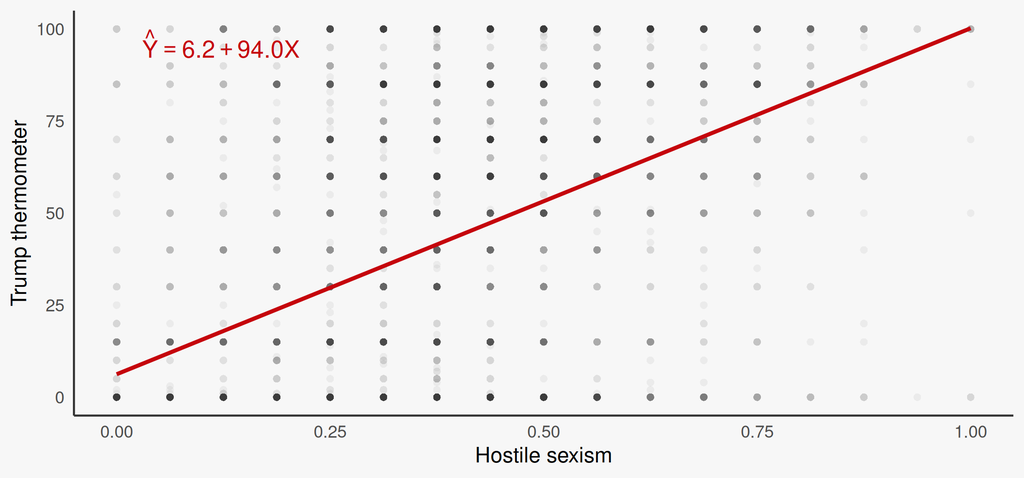

- $\hat{\beta}_1 = 94.0$: respondents a quarter-point apart on the scale differ by 23.5 points on the thermometer, on average
- $\hat{\beta}_0 = 6.2$: the predicted thermometer rating at the **lowest** level of hostile sexism

## Adding partisanship

- Partisanship predicts **both** hostile sexism and feelings about Trump.
  - Add the party dummies, with Democrats as the baseline

  $$\hat{Y}_i = \hat{\beta}_0 + \hat{\beta}_1 X_i + \hat{\beta}_2 X_i^{\text{Ind}} + \hat{\beta}_3 X_i^{\text{Rep}}$$
- Within each party, the fit is a **line** in $X_i$. The lines share a **slope** and have different **intercepts**

  $$\begin{aligned} \text{Democrats:} \quad & \hat{\beta}_0 + \hat{\beta}_1 X_i \\ \text{Independents:} \quad & (\hat{\beta}_0 + \hat{\beta}_2) + \hat{\beta}_1 X_i \\ \text{Republicans:} \quad & (\hat{\beta}_0 + \hat{\beta}_3) + \hat{\beta}_1 X_i \end{aligned}$$
- $\hat{\beta}_2$ and $\hat{\beta}_3$ are the **gaps** between the parallel lines:
  - How much warmer Independents and Republicans are towards Trump than Democrats **with the same** level of hostile sexism
  - Assuming a **common slope** on hostile sexism across the three types of partisans.

## Adding partisanship

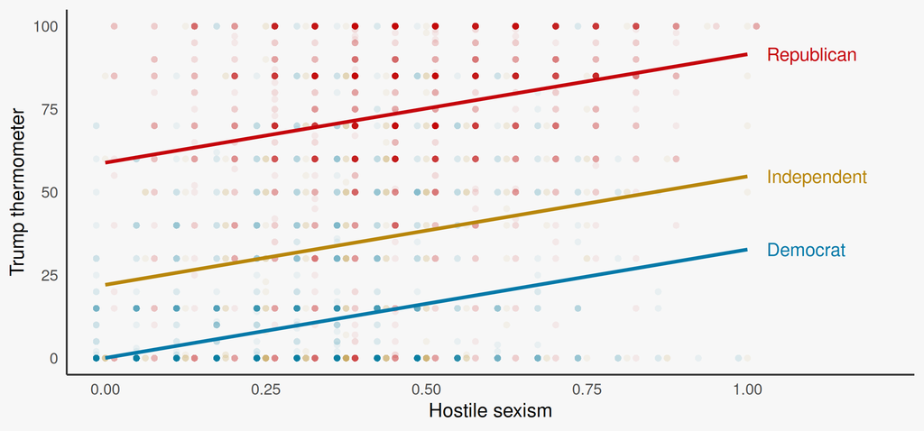

- The slope falls from 94.0 to 32.7. After accounting for the explanatory power of partisanship, the relationship is smaller but **still there**

## Next week

- **Interpreting regression coefficients**
  - Multiple regression and Frisch-Waugh-Lovell
  - Interactions between regression parameters.
- **Inference for regression**
  - The **sampling distribution** of the OLS estimator: consistency and asymptotic normality
  - Confidence intervals and hypothesis tests for regression coefficients
- **Standard errors** for OLS
  - **Heteroskedasticity-consistent** (“robust”) standard errors
  - **Classical** OLS standard errors

## References

American National Election Studies. 2026. *ANES 2024 Time Series Study Full Release*. https://electionstudies.org/data-center/2024-time-series-study/.

Gelman, Andrew, and John Carlin. 2014. “Beyond Power Calculations: Assessing Type s (Sign) and Type m (Magnitude) Errors.” *Perspectives on Psychological Science* 9 (6): 641–51. https://doi.org/10.1177/1745691614551642.

Glick, Peter, and Susan T. Fiske. 1996. “The Ambivalent Sexism Inventory: Differentiating Hostile and Benevolent Sexism.” *Journal of Personality and Social Psychology* 70 (3): 491–512. https://doi.org/10.1037/0022-3514.70.3.491.

Nadaraya, E. A. 1964. “On Estimating Regression.” *Theory of Probability and Its Applications* 9 (1): 141–42. https://doi.org/10.1137/1109020.

Schaffner, Brian F., Matthew MacWilliams, and Tatishe Nteta. 2018. “Understanding White Polarization in the 2016 Vote for President: The Sobering Role of Racism and Sexism.” *Political Science Quarterly* 133 (1): 9–34. https://doi.org/10.1002/polq.12737.

Watson, Geoffrey S. 1964. “Smooth Regression Analysis.” *Sankhyā: The Indian Journal of Statistics, Series A* 26 (4): 359–72.

Winter, Nicholas J. G. 2023. “Hostile Sexism, Benevolent Sexism, and American Elections.” *Politics & Gender* 19 (2): 427–56. https://doi.org/10.1017/S1743923X22000010.